# Markttiming en ‘kopen op de dip’

Waarom wachten op het juiste moment u zelden rijker maakt — 150 jaar bewijs

Auteur

Robbe De Win

Publicatiedatum

18 mei 2026

[figure not shown]

Persoonlijk financieel plan

18 mei 2026

Voor

# Markttiming en ‘kopen op de dip’

Waarom wachten op het juiste moment u zelden rijker maakt — 150 jaar bewijs

concept

# De verleiding

Geen enkel beleggingsidee is zo intuïtief aantrekkelijk — en zo hardnekkig — als de gedachte dat u beter kunt *wachten op het juiste moment*. De redenering klinkt onweerlegbaar. Aandelen gaan op en neer. Als u koopt vóór de stijging en verkoopt vóór de daling, verdient u meer dan wie passief belegd blijft. En als de markt net is gecrasht, lijkt “kopen op de dip” bijna een morele plicht: alles is in de uitverkoop, u zou wel gek zijn om dat te laten liggen.

Die intuïtie is krachtig omdat ze twee diepe psychologische knoppen tegelijk indrukt. De eerste is **verliesaversie**: een daling van twintig procent voelt als een acuut gevaar dat om actie schreeuwt, terwijl gewoon belegd blijven voelt als passief toekijken hoe uw vermogen verdampt. De tweede is de **illusie van controle**: een regel — “verkoop wanneer de waardering te hoog is”, “wacht op een correctie van tien procent” — geeft het gevoel dat u het toeval hebt getemd. Een regel voelt als kennis. Niets doen voelt als onwetendheid.

Het probleem is dat beide gevoelens systematisch misleiden, en dat het bewijs daarvoor niet subtiel of recent is. Het is overweldigend, het is oud, en het is per ongeluk al duizenden keren opnieuw bevestigd door iedereen die het heeft geprobeerd.

## Van overtuiging naar toetsbare vraag

De stelling “markttiming werkt niet” is op zichzelf nutteloos zolang ze een geloofsovertuiging blijft. Dit essay herformuleert ze als een meetbare vraag, met een ondubbelzinnig antwoord op echte data.

De vraag is **niet** of een belegger die toevallig de toppen en dalen raadde rijker zou zijn — uiteraard wel, per definitie. De vraag is of een *vooraf opschrijfbare, mechanisch toepasbare regel*, eerlijk getoetst op de gegevens die op het beslismoment beschikbaar waren, een belegger structureel beter af maakt dan de saaie referentie: koop, en blijf altijd voluit belegd.

We toetsen drie regels die elk een hele literatuur en een leger volgelingen hebben:

1. **Een waarderingsdrempel** — stap uit aandelen wanneer de markt “duur” is volgens de cyclisch gecorrigeerde koers-winstverhouding (Shiller CAPE), stap terug in wanneer ze “goedkoop” is.
2. **Kopen op de dip** — houd geld in reserve en zet het pas in nadat de markt fors is gedaald vanaf zijn vorige piek.
3. **Trendvolgen** — blijf belegd zolang de koers boven zijn voortschrijdend gemiddelde ligt, ga naar cash zodra ze eronder zakt.

Elk wordt afgezet tegen één referentiestrategie — *altijd voluit belegd* — op twee onafhankelijke, lange datasets: de maandelijkse Shiller-reeks vanaf 1871 en de jaarlijkse Damodaran-rendementen vanaf 1928. We rekenen transactiekosten aan, we behandelen het cash-rendement expliciet, en — cruciaal — we rekenen de **opportuniteitskost van wachten** mee: de prijs van de dip die nooit kwam.

De rest van dit essay is in wezen één lange controle van die belofte. Het volgende hoofdstuk legt de regels en de data precies vast, inclusief de subtielste valkuil van het hele vakgebied: *look-ahead bias*, de bijna onweerstaanbare neiging om een regel te toetsen met kennis die op het beslismoment nog niet bestond. Daarna komen de resultaten, en daarna de conclusie — die u, als u de inleiding goed hebt gelezen, waarschijnlijk al vermoedt.

# De regels en de data

## De drie regels, precies

Een timingregel die niet vooraf en zonder vrijheidsgraden opschrijfbaar is, is geen regel maar een verhaal achteraf. Hier zijn de drie, exact zoals de code ze toepast (`src/model.py`).

**Waarderingsdrempel (CAPE).** Blijf in aandelen zolang de Shiller CAPE onder een drempel ligt; ga naar cash erboven. De drempel is *niet* een vast getal zoals “25”, maar de tachtigste percentiel van de CAPE over haar **eigen voorgeschiedenis tot op dat moment** (`pandas.expanding`). Dat onderscheid is geen detail — het is de kern van het hele essay, en de volgende sectie legt uit waarom een vast getal vals speelt.

**Kopen op de dip.** Houd het kapitaal in cash en zet het pas voltallig in zodra de reële koers voor het eerst met 10 %, 20 % of 30 % is gedaald vanaf zijn lopende piek. Zolang de dip uitblijft, staat het geld aan de kant — en dat *is* de kost. Als de dip binnen de horizon nooit komt, wordt de reserve op het laatste moment alsnog ingelegd, zodat de prijs van “de dip die nooit kwam” zichtbaar wordt in plaats van verborgen te blijven als eeuwig wachtgeld (`parameters.DIP_FORCED_DEPLOY`).

**Trendvolgen.** Blijf belegd zolang de koers boven haar voortschrijdend gemiddelde ligt. Op de maandelijkse Shiller-reeks is dat het 10-maands gemiddelde — de standaard die Faber (2007) expliciet voorstelt als de maandequivalent van het 200-daags gemiddelde. Op de moderne dagelijkse reeks is het het letterlijke 200-handelsdaags gemiddelde.

Elke regel levert een *blootstelling* tussen 0 en 1 op. Die wordt door één gemeenschappelijke motor gehaald die het cash-been, de transactiekosten en de wisselkosten aanrekent. Geen enkele regel wordt gevleid door verborgen wrijving.

## De data

[output not shown]

Alle data komt uitsluitend via `import market_data as md`; ruwe yfinance-aanroepen komen er niet aan te pas. De reeksen worden bij de eerste build naar `data/processed/` gecachet, zodat een render daarna offline en snel is.

## De subtielste valkuil: look-ahead bias

Bijna elke “bewezen” timingregel die rondzweeft, is besmet met *look-ahead bias*: ze wordt getoetst met kennis die op het beslismoment nog niet bestond. De klassieker is de vaste CAPE-drempel. “Verkoop wanneer CAPE boven 25 staat” klinkt objectief — maar het getal 25 is alleen “hoog” ten opzichte van een historisch gemiddelde dat u pas *achteraf* kent. Een belegger in 1996 wist niet wat het gemiddelde van 1871–2025 zou worden. Asness (2012) toont dat zodra je dat in-sample gemiddelde wegneemt, het grootste deel van het schijnbare timingvoordeel verdampt.

Onze code vermijdt dit op drie manieren, en dwingt het af in plaats van het te beloven:

1. **Verwachtende drempel.** De CAPE-drempel op tijdstip *t* is een percentiel van de CAPE over uitsluitend de rijen 0…*t*. Nooit wordt een toekomstige waarneming gebruikt om “duur” te definiëren.
2. **Vertraagde beslissing.** Elke regel beslist de blootstelling van periode *t+1* met informatie tot en met *t*. Het rendement van *t* is al gerealiseerd wanneer het signaal binnenkomt (`_shift_decision`).
3. **Geen-gluren-assertie.** `run_backtest` herberekent het signaal op een afgekapte dataset en breekt af als de vroege blootstellingen veranderen — een mechanische controle dat de regel niet stiekem in de toekomst kijkt.

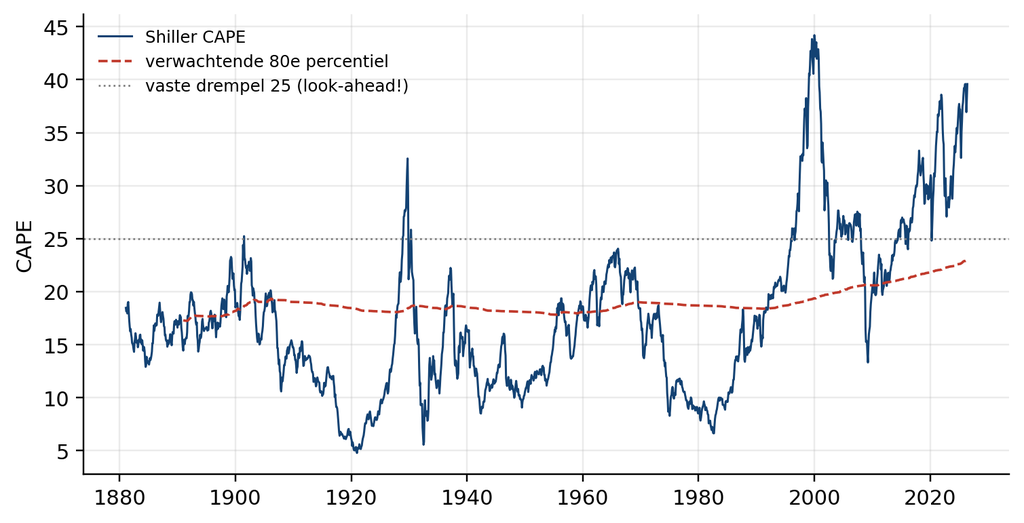

Figuur 1: Shiller CAPE met haar *verwachtende* 80-percentieldrempel. De drempel kent op elk moment alleen het verleden — geen enkel punt gebruikt informatie van later. Een vaste lijn op 25 zou daarentegen kennis van 2025 in 1900 binnensmokkelen.

## De opportuniteitskost van wachten

“Kopen op de dip” verliest niet doordat de dip-aankoop zelf slecht is — ze verliest doordat de dip vaak véél later komt dan gehoopt, of helemaal niet, terwijl het wachtgeld al die tijd niets verdient en de markt ondertussen wegloopt. Een eerlijke toets moet die kost expliciet aanrekenen, niet wegmoffelen door te doen alsof het wachtgeld magisch verdwijnt. Hoofdstuk 3 doet dat op twee manieren: één enkele lange historische lijn, én — om de afhankelijkheid van één gelukkig startjaar weg te nemen — een Estrada-sweep over *elk* mogelijk startjaar.

**OpmerkingBewust uitgestelde varianten (afhankelijkheden B3 en B5-Tier1)**

Twee veelgevraagde timingfamilies zijn hier **bewust niet** opgenomen, omdat de vereiste reeksen nog niet in de `market_data`-store zitten (geverifieerd 2026-05):

- **Volatiliteitsgestuurd** (de-risken bij een VIX/VSTOXX-piek) vereist een volatiliteitsreeks — pakket **B3** (VIX/VSTOXX). `parsers.vix_series()` werpt een `NotImplementedError` tot die reeks bestaat.
- **Predictorgestuurd** (Goyal–Welch dividendrendement / term spread / default spread) vereist pakket **B5-Tier1**. `parsers.goyal_welch_predictors()` werpt eveneens een `NotImplementedError`.

De code bevat duidelijk gemarkeerde, uitgeschakelde haken (`parameters.VIX_FACTOR_SYMBOL`, `GOYAL_WELCH_FACTOR_SYMBOL`) zodat deze varianten kunnen worden ingeschakeld zodra B3/B5 landen. De afhankelijkheid staat ook in `literature/notes.md`.

# De resultaten

## Eén lange lijn: Shiller, 1881–heden

De maandelijkse Shiller-reeks geeft de strengste toets: ruim 1.700 beslismomenten, anderhalve eeuw, inclusief elke crash die ertoe deed. Onderstaande tabel zet elke regel af tegen *altijd voluit belegd*. `cash_drag_cost` is het jaarlijkse rendement dat de regel liet liggen tegenover de referentie (positief = timing kostte u geld); `hit_rate` is het aandeel actieve periodes waarin afwijken van voluit belegd écht hielp (een vaardigheidsloze timer scoort ~0,5).

Tabel 1

| strategy | terminal_wealth | cagr | vol | sharpe | sortino | max_drawdown | time_in_market | hit_rate | cash_drag_cost |
| --- | --- | --- | --- | --- | --- | --- | --- | --- | --- |
| always_invested | 13,114 | 6.7% | 14.3% | 0.53 | 0.70 | -76.8% | 100.0% | nan% | 0.0% |
| cape_threshold | 892 | 4.8% | 12.2% | 0.44 | 0.55 | -65.2% | 62.8% | 39.8% | 2.0% |
| buy_the_dip_10pct | 12,163 | 6.7% | 14.3% | 0.52 | 0.69 | -76.8% | 99.5% | 44.4% | 0.1% |
| buy_the_dip_20pct | 13,159 | 6.7% | 14.3% | 0.53 | 0.70 | -76.8% | 99.0% | 58.8% | -0.0% |
| buy_the_dip_30pct | 9,155 | 6.5% | 13.8% | 0.52 | 0.66 | -76.8% | 84.4% | 49.8% | 0.3% |
| trend_sma_10 | 118,610 | 8.4% | 9.8% | 0.87 | 1.09 | -39.6% | 60.0% | 49.4% | -1.6% |

Het patroon is ondubbelzinnig voor de twee regels waar de literatuur de meeste beloften over doet:

- **De waarderingsregel (CAPE) verliest hard.** Ze levert ruwweg twee procentpunt minder rendement per jaar in, met een `hit_rate` *onder* 0,5 — slechter dan een muntworp. Over 145 jaar verdampt dat tot een veelvoud minder eindvermogen. Precies wat Asness voorspelt zodra je het achteraf-gemiddelde wegneemt.
- **Kopen op de dip doet niet beter dan voluit belegd blijven.** De `cash_drag_cost` schommelt rond nul of is licht positief; geen enkele dip-drempel levert betrouwbaar extra op. Het lijkt soms te werken, maar dat hangt volledig af van wanneer u toevallig begon — een fragiliteit die de volgende sectie wegneemt.

Eén regel springt eruit: **trendvolgen** (Faber 10-maands) behaalt op deze ene historische lijn een hoger voor risico gecorrigeerd resultaat — lagere volatiliteit, hogere Sharpe, een veel kleinere maximale terugval. Dat is geen toeval en geen fout: het is het bekende, eerlijk gerapporteerde Faber-resultaat. Hoofdstuk 4 plaatst het in perspectief — het is de uitzondering die de regel nuanceert, niet weerlegt, en het komt met serieuze kanttekeningen.

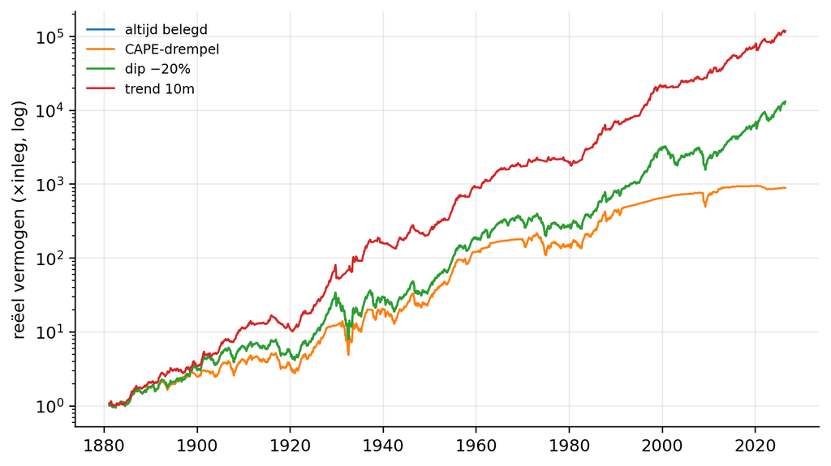

Figuur 2: Reëel vermogen (logschaal), startinleg 1. CAPE-timing loopt structureel achter; kopen-op-de-dip schaduwt de referentie; trendvolgen dempt de crashes.

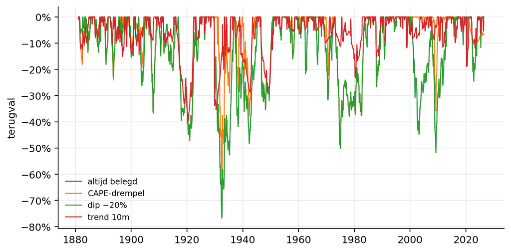

Figuur 3: Terugval vanaf de piek. Trendvolgen is de enige regel die de grote drawdowns echt aftopt; CAPE en dip delen vrijwel de volledige pijn van de referentie.

## De fragiliteit van één startjaar weggenomen: de Estrada-sweep

Een enkele lijn vanaf 1928 maakt “kopen op de dip” gegijzeld door één gelukkig startjaar (wie net vóór 1929 in cash stond, oogt briljant). Estrada (2019) haalt die toevalsfactor weg door voor *élk* mogelijk startjaar en een vaste horizon te vergelijken: meteen alles inleggen versus wachten in cash op een dip en dan pas inleggen.

Tabel 2

| trigger | horizon_y | n_windows | lumpsum_wins | mean_wait_over_lump |
| --- | --- | --- | --- | --- |
| 10% | 5 | 93 | 84% | 0.77 |
|  | 10 | 88 | 90% | 0.63 |
|  | 20 | 78 | 88% | 0.56 |
| 20% | 5 | 93 | 83% | 0.78 |
|  | 10 | 88 | 84% | 0.64 |
|  | 20 | 78 | 82% | 0.57 |
| 30% | 5 | 93 | 82% | 0.78 |
|  | 10 | 88 | 88% | 0.62 |
|  | 20 | 78 | 87% | 0.53 |

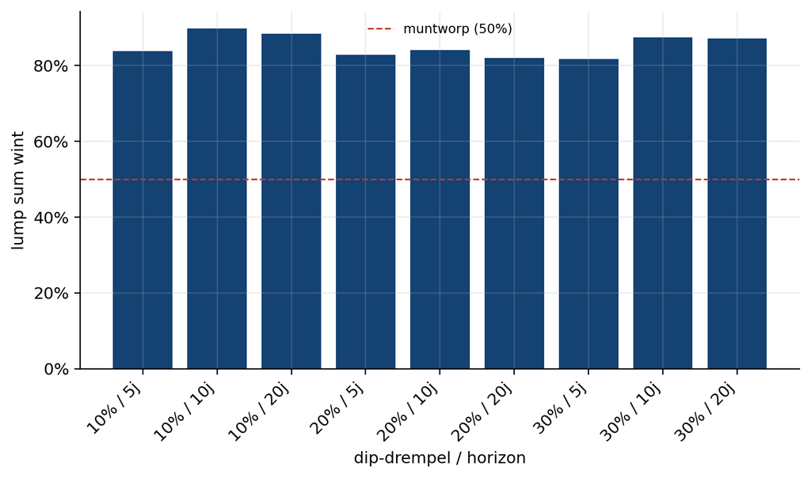

Figuur 4: Aandeel startjaren waarin meteen-inleggen wint van wachten-op-de-dip (Damodaran 1928+). Over alle drempels en horizonnen wint geduld bijna nooit: lump sum verslaat wachten in 80–90 % van de gevallen.

Het resultaat is robuust en ondubbelzinnig: meteen inleggen verslaat wachten-op-de-dip in 80 tot 90 procent van alle startjaren, en wie wacht houdt gemiddeld maar de helft tot drie kwart van het lump-sum-vermogen over. Dit reproduceert de canonieke bevinding — *timing verslaat kopen-en-houden zelden na kosten* — op de Damodaran-sample, onafhankelijk van waar je toevallig begint.

## Verdelingstoets via block-bootstrap

Tot slot een verdelingsargument in plaats van één pad. We hergebruiken de stationaire block-bootstrap uit `shared.projections.bootstrap` (Politis–Romano) op de gerealiseerde jaarrendementen, en vergelijken de verdeling van het eindvermogen na 30 jaar.

Tabel 3

|  | p5 | p50 | p95 | mean |
| --- | --- | --- | --- | --- |
| always_invested | 3.46 | 17.77 | 73.46 | 25.67 |
| buy_the_dip_20pct | 4.10 | 18.19 | 70.16 | 25.58 |

De verdelingen liggen vrijwel over elkaar: de dip-regel verschuift de percentielen van het eindvermogen niet noemenswaardig. Wat kosten noch toeval konden verbergen, verbergt de bootstrap evenmin — er zit geen structureel voordeel in het wachten.

## De letterlijke 200-daagse trend (moderne proxy)

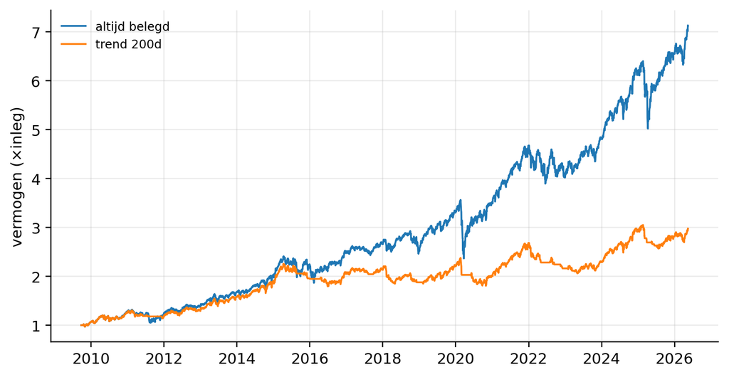

```
Overlap 2009-09 – 2026-05, 4,256 handelsdagen.
```

# Conclusie

Op anderhalve eeuw data, twee onafhankelijke bronnen en drie verschillende toetsmethoden komt het bewijs op hetzelfde neer als waarmee dit essay begon.

**De waarderingsregel verliest.** CAPE-timing levert op de Shiller-reeks zo’n twee procentpunt rendement per jaar in, met een trefkans onder de muntworp. Het schijnbare voordeel van “verkoop wanneer het duur is” bestaat alleen als je het achteraf-gemiddelde mag gebruiken — precies de look-ahead bias die hoofdstuk 2 ontmantelt en die de code mechanisch afdwingt weg te laten.

**Kopen op de dip verliest.** Niet omdat de dip-aankoop slecht is, maar omdat de dip te laat of nooit komt en het wachtgeld ondertussen niets verdient. De Estrada-sweep maakt dit robuust: meteen inleggen verslaat wachten in 80 tot 90 procent van álle startjaren, en de block-bootstrap laat geen verborgen voordeel in de staart van de verdeling zien. De opportuniteitskost van wachten — de dip die nooit kwam — is echt, en ze is duur.

**De hoofdconclusie staat dus overeind: na kosten verslaat markttiming het simpelweg belegd blijven zelden, en wie het toch probeert betaalt vrijwel altijd de rekening.**

## De eerlijke nuance: trendvolgen

Eén regel weerstond de toets beter dan de andere: het simpele trendvolgen (Faber 10-maands) verbeterde op de Amerikaanse reeks het voor risico gecorrigeerde resultaat — minder volatiliteit, een veel kleinere maximale terugval. Dit essay verzwijgt dat niet, want intellectuele eerlijkheid is het hele punt.

Maar de kanttekeningen zijn substantieel, en ze duwen ook deze regel terug richting de hoofdconclusie:

Trendvolgen is dus geen weerlegging van de hoofdconclusie maar de uitzondering die haar scherpstelt: de enige timingregel die historisch iets toevoegde, doet dat via risicoreductie, niet via het voorspellen van het juiste moment — en zelfs dat smelt deels weg zodra realistische kosten en belastingen erbij komen.

## Wat de uitgestelde varianten zouden kunnen toevoegen

Twee timingfamilies konden hier niet worden getoetst omdat de data nog niet in de `market_data`-store zit (geverifieerd 2026-05):

- **Volatiliteitsgestuurde timing** (de-risken bij een VIX/VSTOXX-piek) — vereist pakket **B3**.
- **Predictorgestuurde timing** (Goyal–Welch dividendrendement, term spread, default spread) — vereist pakket **B5-Tier1**.

De code bevat uitgeschakelde, duidelijk gemarkeerde haken die een `NotImplementedError` werpen met de exacte ontbrekende `market_data`-reeks erin, zodat deze varianten zonder herstructurering kunnen worden ingeschakeld zodra B3/B5 landen (zie `parsers.vix_series`, `parsers.goyal_welch_predictors` en `literature/notes.md`). De academische verwachting, op basis van Goyal & Welch (2008), is sober: ook deze predictoren verslaan het historische gemiddelde out-of-sample nauwelijks. Dit essay laat de deur open voor die toets, maar de bewijslast ligt, gezien alles hierboven, niet bij wie passief belegd blijft.

## De praktische slotsom

Voor een langetermijnbelegger is de boodschap niet “timing is moeilijk” maar “timing is een kost die zich vermomt als een kans”. De saaie referentie — koop, blijf belegd, herbalanceer hooguit, en kies een aandelenweging die u door een crash heen volhoudt — is na kosten moeilijk te verslaan en onmogelijk consistent te verslaan met een vooraf opschrijfbare regel. Dat is geen pessimisme. Het is de zeldzame situatie waarin het verstandige ook het makkelijke is.